# Principal Component Analysis

En esta sección, exploramos lo que es quizás uno de los algoritmos de clasificacion no supervisada más ampliamente utilizados, el análisis de componentes principales (PCA). El PCA es fundamentalmente un algoritmo de reducción de dimensionalidad, pero también puede ser útil como herramienta para la visualización, para el filtrado de ruido, para la extracción de características, y mucho más. Después de una breve discusión conceptual del algoritmo PCA, veremos un par de ejemplos de estas aplicaciones adicionales.

Comenzamos con las importaciones estándar:

```python
!pip install seaborn
```

```python
%matplotlib inline
import numpy as np
import matplotlib.pyplot as plt
import seaborn as sns; sns.set()
```

## Introduccion de los PCA

El análisis de componentes principales (PCA) es un método rápido y flexible sin supervisión para la reducción de la dimensionalidad en los datos. Su comportamiento es más fácil de visualizar al observar un conjunto de datos bidimensionales. Considere los siguientes 200 puntos:

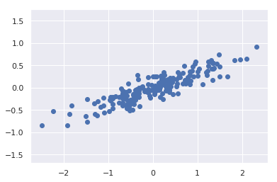

```python
rng = np.random.RandomState(1)
X = np.dot(rng.rand(2, 2), rng.randn(2, 200)).T
plt.scatter(X[:, 0], X[:, 1])
plt.axis('equal');
```

A simple vista, está claro que existe una relación casi lineal entre las variables x e y.

En el análisis de componentes principales, esta relación se cuantifica encontrando una lista de los *ejes principales* en los datos, y utilizando esos ejes para describir el conjunto de datos. Usando el estimador `PCA` de Scikit-Learn, podemos calcular esto de la siguiente manera:

```python
from sklearn.decomposition import PCA
pca = PCA(n_components=2)
pca.fit(X)
```

```
PCA(copy=True, iterated_power='auto', n_components=2, random_state=None,
  svd_solver='auto', tol=0.0, whiten=False)
```

El entrenamiento aprende algunas cantidades de los datos, lo que es más importante, los "componentes" y la "varianza explicada":

```python
print(pca.components_)
```

```
[[-0.94446029 -0.32862557]
 [-0.32862557  0.94446029]]
```

```python
print(pca.explained_variance_)
```

```
[0.7625315 0.0184779]
```

Para ver qué significan estos números, visualicemos como vectores sobre los datos de entrada, usando los "componentes" para definir la dirección del vector, y la "varianza explicada" para definir la longitud al cuadrado del vector:

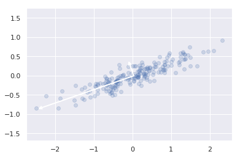

```python
def draw_vector(v0, v1, ax=None):
    ax = ax or plt.gca()
    arrowprops=dict(arrowstyle='->',
                    linewidth=2,
                    shrinkA=0, shrinkB=0)
    ax.annotate('', v1, v0, arrowprops=arrowprops)

# plot data
plt.scatter(X[:, 0], X[:, 1], alpha=0.2)
for length, vector in zip(pca.explained_variance_, pca.components_):
    v = vector * 3 * np.sqrt(length)
    draw_vector(pca.mean_, pca.mean_ + v)
plt.axis('equal');
```

Estos vectores representan los *ejes principales* de los datos, y la longitud del vector es una indicación de cuán "importante" es ese eje al describir la distribución de los datos; más precisamente, es una medida de la varianza de los datos. cuando se proyecta sobre ese eje. La proyección de cada punto de datos sobre los ejes principales son los "componentes principales" de los datos.

Si trazamos estos componentes principales junto a los datos originales, vemos los gráficos que se muestran aquí:

[figure not shown]

figure source in Appendix

Esta transformación de ejes de datos a ejes principales es una *transformación afín* , que básicamente significa que se compone de una traslación, rotación y escala uniforme.

Si bien este algoritmo para encontrar componentes principales puede parecer una simple curiosidad matemática, resulta que tiene aplicaciones de gran alcance en el mundo del aprendizaje automático y la exploración de datos.

### PCA para reducción de la dimensionalidad

Este es un ejemplo del uso de PCA como una transformación de reducción de dimensionalidad:

```python
pca = PCA(n_components=1)
pca.fit(X)
X_pca = pca.transform(X)
print("original shape:   ", X.shape)
print("transformed shape:", X_pca.shape)
```

```
original shape:    (200, 2)
transformed shape: (200, 1)
```

Los datos transformados se han reducido a una sola dimensión. Para comprender el efecto de esta reducción de la dimensionalidad, podemos realizar la transformación inversa de estos datos reducidos y trazarla junto con los datos originales:

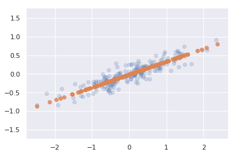

```python
X_new = pca.inverse_transform(X_pca)
plt.scatter(X[:, 0], X[:, 1], alpha=0.2)
plt.scatter(X_new[:, 0], X_new[:, 1], alpha=0.8)
plt.axis('equal');
```

Los puntos de luz son los datos originales, mientras que los puntos oscuros son la versión proyectada. Esto deja en claro lo que significa una reducción de la dimensionalidad de PCA: la información a lo largo del eje o ejes principales menos importantes se elimina, dejando solo el componente (s) de los datos con la varianza más alta. La fracción de varianza que se corta (proporcional a la dispersión de puntos alrededor de la línea formada en esta figura) es aproximadamente una medida de cuánta "información" se descarta en esta reducción de la dimensionalidad.

Este conjunto de datos de dimensión reducida es en algunos sentidos "lo suficientemente bueno" para codificar las relaciones más importantes entre los puntos: a pesar de reducir la dimensión de los datos en un 50%, la relación general entre los puntos de datos se conserva en su mayoría.

## Resumen de PCA

En las siguientes secciones, vamos a ver otros métodos de aprendizaje no supervisado que se basan en algunas de las ideas de la PCA.